# Drinking Behaviors

## Technical Description

by Alyssa Holzer, Austin Hutchinson, Lee Polla, & Suraj Chandrasekhar

## Introduction

Alcohol is typically perceived as something that hinders performance. A common example of this is drinking while driving. At the same time, there is this notion of the Ballmer Peak where a few drinks in moderaiton can improve purformance during tasks like writing code. Similarly, there are also mixed opnions about whether or not drinking alcohol influences your sober behavior for better or for worse; like if someone wakes up with a hangover, or another peroson wakes up feeling energized after having fun or destressing. Based on our recommendations, students can make decisions about their drinking habits, such that they peform their best in school.

### Decision Context

Our research question asks how should students drink throughout the quarter if they want to optimize their GPA.The goal of this study is to help college students make informed decisions about what kinds of drinking behaviors they should adopt over the course of a school term with the ideal outcome being good grades. Some possible decisions college students can make include: abstain from alcohol, consume a moderate amount of alcohol by only drinking on weekends or setting a limit on how much or how often to drink over a period of time, or drink regularly everyday of the week. There are some assumptions that are usually made about alcohol and its effects. These include the assumptions that alcohol can be highly addictive, drinking kills brain cells, has mind altering effects, and is generally not conducive to good performance in school.

For each choose on how much alcohol to consume as a student, there are two distinct outcomes. One is that you get good grades and the other is that you get poor grades. Most students would want to get the best grades they can possibly get.

We are interested in how alcohol will influence students’ grades’ because we think that much of the other alcohol recommendations that students typically receive is only in terms of health and legality. We think that other students will be more receptive to our recommendations that are based on performance, because they are interested in doing well in school, and the students who don’t care about heath or legality issues might be making decisions without being very informed at all. Universities and other educational institutions should also be interested in our results as a means to promote better student performance. Educational institutions will also likely be concenered over alcohol related issues on campuses, so we must be clear in that we are not advising students to participate in underage drinking or posession of alcohol when prohibited.

## Method

To answer the quesiton of how much college student should drink if they want to optimize their grades, we anlyzed three separate datasets on other research related to student term grades and their drinking factors, and include several other possibly related factors. The purpose of using multiple datasets in our anaysis is to try to triangulate between them and see if the same kinds of patterns and results are found across different contexts. The more consistent our results are across the three datasets, the more generalizable our findings might be.

Our last dataset was found on StatCrunch and contained data from a study done on college students and measured variables like sleep times, gpa, drinking and various psychological test scores. The outcome variable that we used was GPA, which represented the student’s grade on a 4.0 scale for that semester. The predictor vairables we examined were Drinks and ClassesMissed. Drinks represented the count of alcoholic beverages that the student consumed on a weekly basis. ClassesMissed represented the number of classes that the student missed over the course of that semester.

All three of our datasets were pretty clean to begin with in that they were not missing any entries and the individual observations did not seem inaccurate in any way. After reviewing the datasets, there were some factors that we decided we were not intestested in, which we filtered out. For instance, the UCI dataset contains data on first and second period grades, which were strongly correlated with final grades, however we were more interested in the correlations between outside factors so we removed those two factors from our analysis.

For the Michigan dataset, we decided to separate the data into two groups to see if the most important factors for predicting GPA were different between people who drink a little verusus people who drink a lot.

To analyze the relationship between alcohol and grades, we created linear models for each of the datasets and checked the correlation values between the outcome and predictor varables to check the accuracy of these models. We feel that this method was appropriate because we were primarily interested in whether or not there was a real correlation between the amount of alcohol a student consumes and their grades.

## Data Analysis

### Alcohol Consumption vs. Grades

#### UCI Dataset

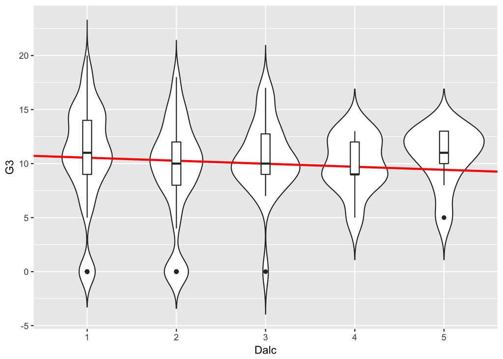

```r
# load uci data
uci_data <- read.csv("./student-mat.csv", stringsAsFactors = FALSE)

# fit linear model for G3 using Dalc
dalc_linear_model <- lm(G3 ~ Dalc, data=uci_data)
# coefficients from model
dalc_parameters <- tidy(dalc_linear_model)$estimate

# Violin plots with linear model
uci_data$Dalc <- as.factor(uci_data$Dalc)
p <- ggplot(uci_data, aes(x = Dalc, y = G3)) +
  geom_violin(trim = FALSE) +
  geom_abline(slope=dalc_parameters[2], intercept=dalc_parameters[1], size = 1, color = "red") +
  geom_boxplot(width=0.1)
p
```

We chose to use a violin plot as opposed to a scatterplot to visualize this data because it is more helpful for showing the density of the distribution for each discrete value of Dalc. The boxplots were added mostly to show the mean final grade for each value of Dalc. More of the data is concentrated on the left side of the graph, which is unsurprising as this data comes from high school students. As you can see, the means are all fairly similar across students regardless of level of alcohol consumption, though the linear model created shows a slightly negative correlation between G3 and Dalc.

```r
cor(as.numeric(uci_data$Dalc), uci_data$G3)
```

```
## [1] -0.05466004
```

Above is the Pearson correlation coefficent and is used here to measure the linear dependence between Dalc and G3. The resulting value is very small, which indicates there is very little correlation between the two variables. It is especially hard to say anything about the correlation between Dalc and G3 because far more students responded with a 3 or below for Dalc than those that reponded with 4 or above.

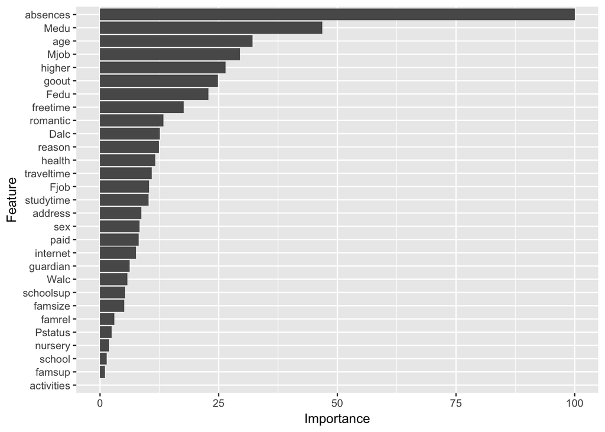

```r
# feature selection

# remove period 1 and 2 grades
final_grade_features <- uci_data %>% dplyr::select(-failures, -G1, -G2)
# k-folds cross-validation
control <- trainControl(method="repeatedcv", number = 10, repeats = 3)
model <- train(G3 ~., data=final_grade_features, method = "knn", trControl = control)
importance <- varImp(model)
ggplot(importance)
```

To understand which variables are actually most important for predicting final grades we used feature selection, ranking features using K-Nearest Neighbors. As is shown in the chart above, the results show that absences are the most important feature for predicting G3. Dalc is ranked tenth, which strengthens our previous conclusion that there is only a weak correlation between Dalc and G3. A different feature, Walc, represents weekend alcohol consumption, and is a numeric value ranging from 1 (very low workday alcohol consumption) to 5 (very high workday alcohol consumption). We chose not to investigate the relationship between weekend alcohol consumption and final grades because it is ranked twenty-first in the chart above, which is even lower than the ranking for Dalc, meaning there probably wouldn’t be a very strong correlation.

#### Michigan Dataset

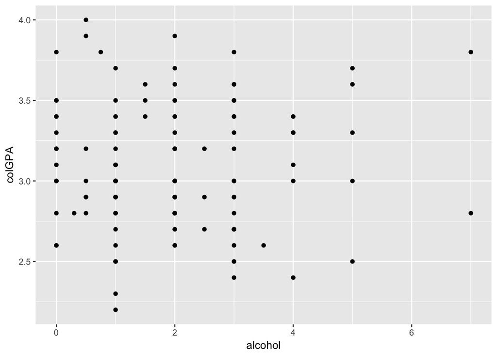

```r
# load data
mich_data <- read.csv("./gpa1.csv")
mich_data <- mich_data %>% dplyr::select(-X)
#split into two groups
low_drink <- mich_data %>% filter(alcohol < 3)
high_drink <- mich_data %>% filter(alcohol >= 3)

# scatter plot with linear model
all_plot <- ggplot(mich_data, aes(x = alcohol, y = colGPA))  +
  geom_point()
all_plot
```

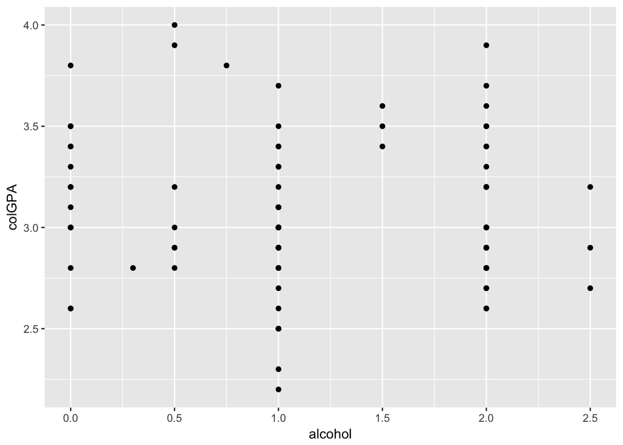

```r
low_plot <- ggplot(low_drink, aes(x = alcohol, y = colGPA))  +
  geom_point()
low_plot
```

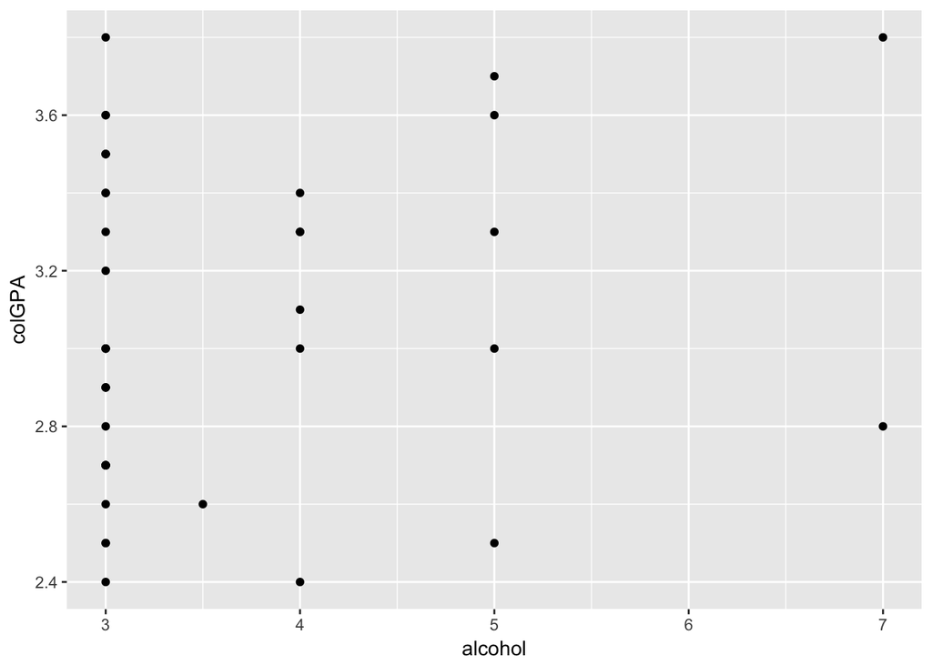

```r
high_plot <- ggplot(high_drink, aes(x = alcohol, y = colGPA))  +
  geom_point()
high_plot
```

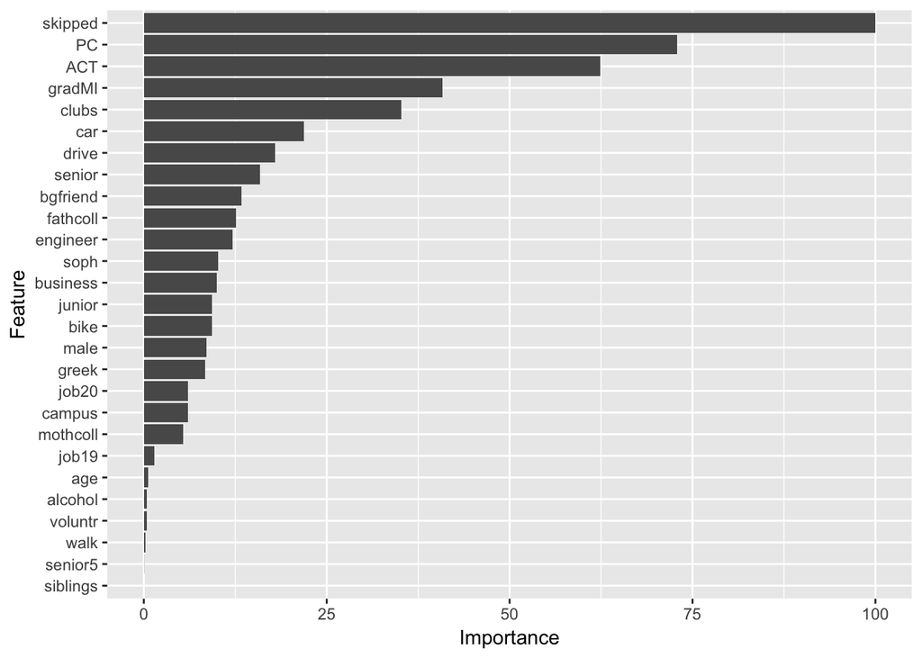

```r
# feature selection
# all data
control <- trainControl(method="repeatedcv", number = 10, repeats = 3)
colGPA_features <- mich_data %>% dplyr::select(-hsGPA)

model1 <- train(colGPA ~., data=colGPA_features, method = "knn", trControl = control)

importance1 <- varImp(model1)

ggplot(importance1)
```

To understand which variables are actually most important for predicting final creates we used feature selection, ranking features using K-Nearest Neighbors. As is shown in the chart above, the results show that absences are the most important feature for predicting GPA. Alchol was actually the fifth least important factor when it comes to college GPA, as it is almost negligible when it comes to college GPA, which we also see in our scatter plot above.

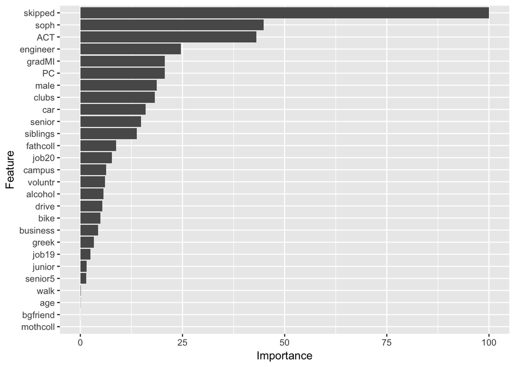

```r
# low
control <- trainControl(method="repeatedcv", number = 10, repeats = 3)
colGPA_features_low <- low_drink %>% dplyr::select(-hsGPA)

model_low <- train(colGPA ~., data=colGPA_features_low, method = "knn", trControl = control)

importance_low <- varImp(model_low)

ggplot(importance_low)
```

We did a similar important factor analysis for the people who do not drink or drink moderately. We removed high school GPA from our factor analysis because it was significantly more important than any other factor, and it makes logical sense because people who are good students in high school are most likely going to be good students in college. Skipped classes was once again the most important factor to college GPA, and alcohol was not as important as a factor, as it is not one of the top 10 most important factors. One thing we found interesting is that most important factors deal with more academic issues, such as class standing, their ACT scores, if they are an engineering student, or if they went to a Michigan high school

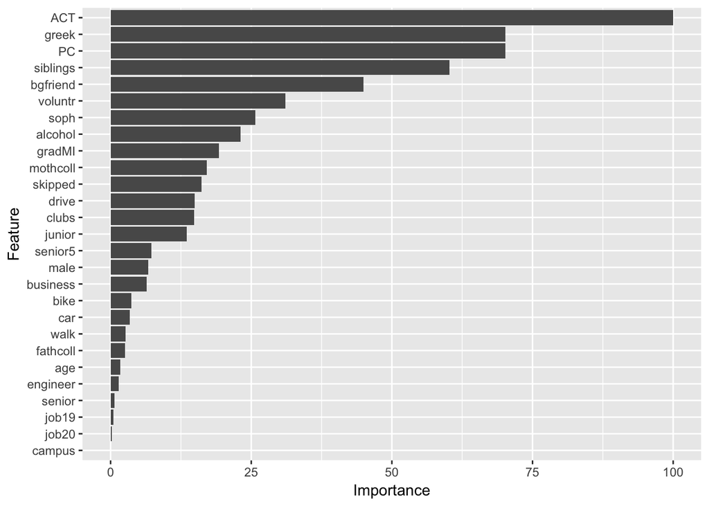

```r
# high
control <- trainControl(method="repeatedcv", number = 10, repeats = 3)
colGPA_features_high <- high_drink %>% dplyr::select(-hsGPA)

model_high <- train(colGPA ~., data=colGPA_features_high, method = "knn", trControl = control)

importance_high <- varImp(model_high)
ggplot(importance_high)
```

We also did a similar important factor analysis for the people who drink more frequently. We once again removed high school GPA from our factor analysis because it was significantly more important than any other factor, and it makes logical sense because people who are good students in high school are most likely going to be good students in college. ACT grades were the most important factor to college GPA, and alcohol was more important as a factor, as it was one of the top 10 most important factors. One thing we found interesting is that most important factors deal with more social issues, such as having a boyfriend or girlfriend, being in the greek system, having siblings, and volunteering.

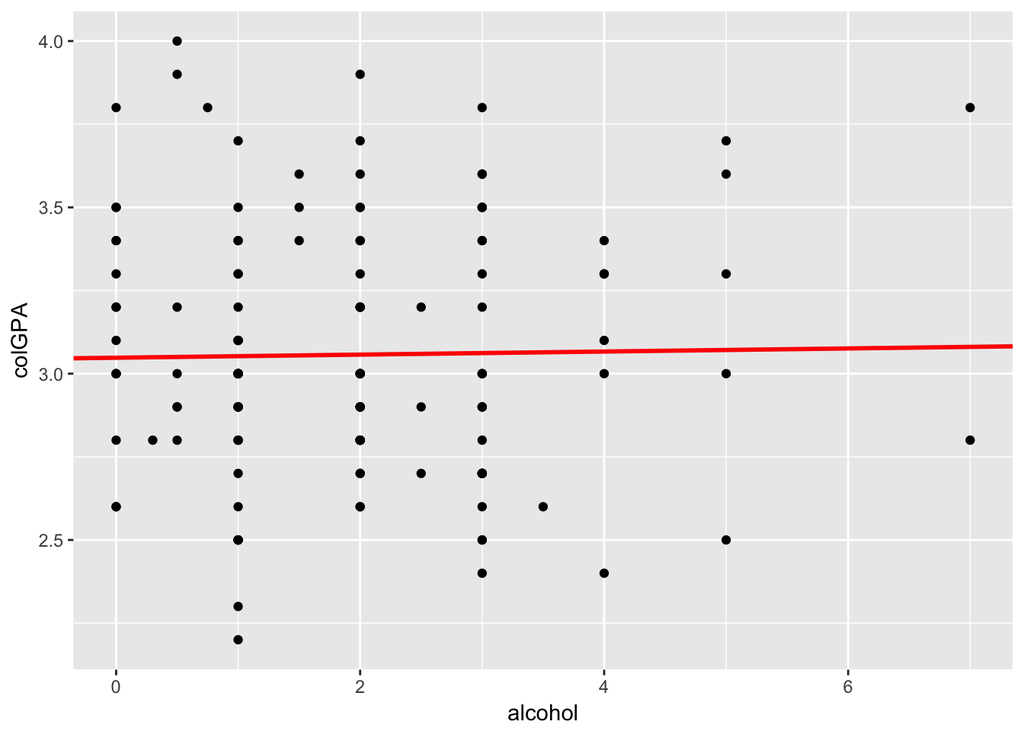

```r
# fit linear model for colGPA using alcohol
alcohol_linear_model <- lm(colGPA ~ alcohol, data=mich_data)
# coefficients from model
alcohol_parameters <- tidy(alcohol_linear_model)$estimate
# plot data with linear model
p <- ggplot(data=mich_data) + geom_point(aes(x=alcohol, y=colGPA))
p + geom_abline(slope=alcohol_parameters[2], intercept=alcohol_parameters[1], size = 1, color = "red")
```

```r
#correlation
cor(mich_data$alcohol,mich_data$colGPA)
```

```
## [1] 0.01718657
```

Above, we performed a linear regression and found a line that was almost horizontal, as the slope was very close to 0. We also looked into the correlation between alcohol and college GPA, and found the correlation value to be 0.017, which is a very weak positive relationship and signifying that there is almost no relationship between alcohol and college GPA.

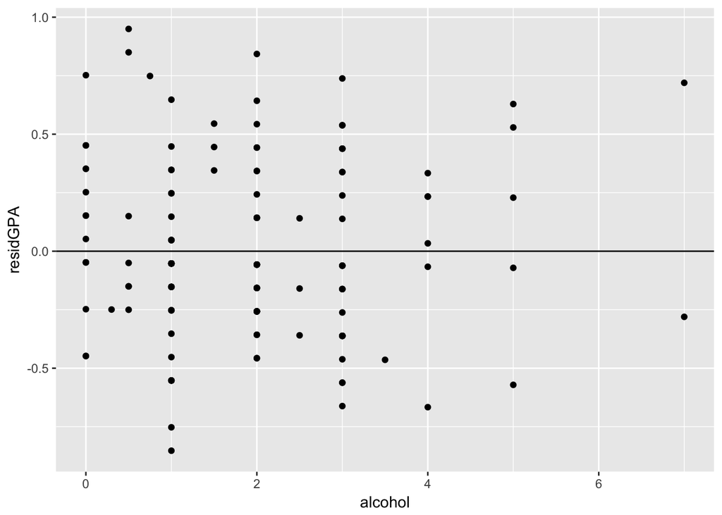

```r
# Residuals
mich_data$predAlc <- alcohol_parameters[2] * mich_data$alcohol + alcohol_parameters[1]
mich_data$residGPA <- mich_data$colGPA - mich_data$predAlc
p3 <- ggplot(data=mich_data) + geom_point(aes(x=alcohol, y=residGPA))
p3+geom_abline(slope=0, intercept = 0)
```

We also performed a residual analysis on our regression to make sure that we chose the right model instead of a quadratic regression. Based on our residual graph above, the linear regression was appropriate as they values were fairly close to 0 and was pretty random in being over or under the line.

#### Sleep Study Dataset

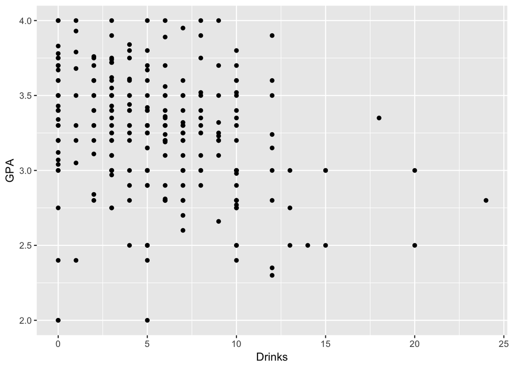

```r
# load data
sleep_data <- read.csv("./Sleep Drinking - Sheet1.csv")
sleep_data <- sleep_data %>% dplyr::select(-LarkOwl, -DepressionStatus, -AnxietyStatus, -Stress)

# scatter plot
p <- ggplot(sleep_data, aes(x = Drinks, y = GPA))  +
  geom_point()
p
```

We removed all of the computed columns from the data set and used the values that determined them instead. The initial plot made for Drinks and GPA showed that most of the data is clustered in the region with little weekly drinking and high GPA.

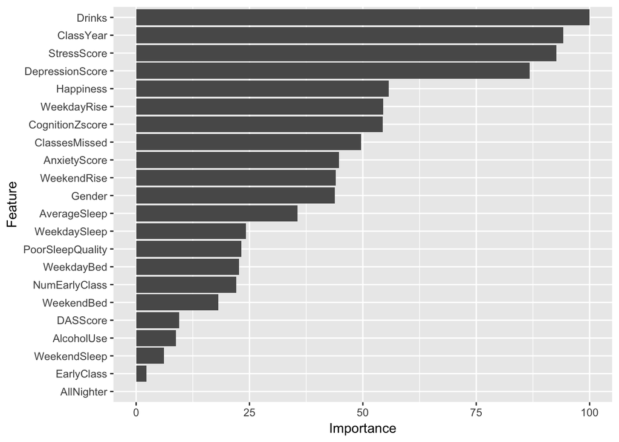

```r
# feature selection
control <- trainControl(method="repeatedcv", number = 10, repeats = 3)
model <- train(GPA ~., data=sleep_data, method = "knn", trControl = control)
importance <- varImp(model)
ggplot(importance)
```

To determine which of the variables in our data set would be the best predictor of GPA, we used the same KNN feature selection technique that we used for the other data sets. We found that Drinks was actually the most important factor for GPA. The other important finding in this chart is that classes missed is only moderately important to GPA, which is represented by an importance score of about 50 and only ranking as the 8th most important feature.

```r
model_linear_function <- function(a, data) {
  a[1] + data$Drinks * a[2]
}

drinks_lm_function = model_linear_function

drinks_measure_distance_mad <- function(mod_params, data) {
  diff <- data$GPA - drinks_lm_function(mod_params, data)
  mean(abs(diff))
}

# use mean absolute function to get distance
drinks_mad_fit <- optim(c(3.4, 0), drinks_measure_distance_mad, data = sleep_data)
drinks_mad_fit$par
```

```
## [1]  3.4411670 -0.0282334
```

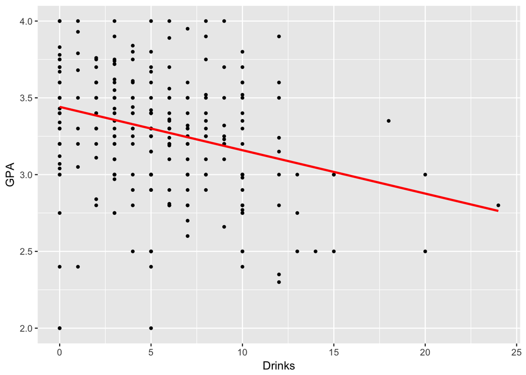

```r
sleep_data_small <- sleep_data %>%
  mutate(lm_mad = drinks_mad_fit$par[1] + drinks_mad_fit$par[2] * sleep_data$Drinks)

ggplot(sleep_data_small , aes(Drinks)) +
  geom_point(aes(y= GPA), size = 1) +
  geom_line(aes(y= lm_mad), size = 1, colour = "red")
```

We decided to construct a linear model for our drinks by GPA plot using an absolute value function to fit our line, because the data was so tightly clustered in one part whil other regions were much more sparse. But given our model, we would predict that student grades would decrease by .03 grade points from 3.44 for every weekly drink they have.

```r
cor(sleep_data$Drinks, sleep_data$GPA)
```

```
## [1] -0.2693046
```

This is the correlation value between drinks and GPA, and we believe that it is high enough to indicate a moderate negative relationship between Drinks and GPA.

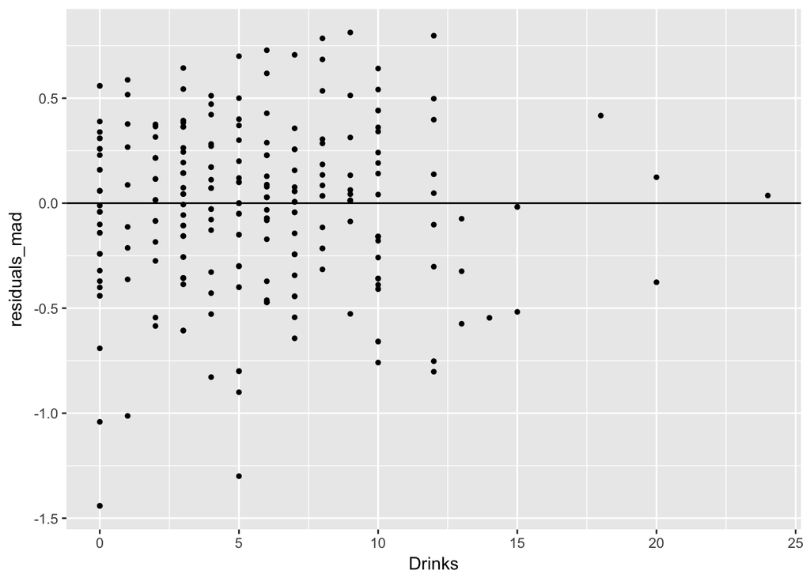

```r
sleep_data_small <- sleep_data_small %>%
  mutate(
    residuals_mad = GPA - lm_mad,
    residuals = GPA - lm_mad
  )

# plot the residuals to compare them
ggplot(sleep_data_small, aes(Drinks)) +
  geom_point(aes(y=residuals_mad), size = 1) +
  geom_abline(intercept=0, slope = 0)
```

We constructed this residual plot to evaluate our linear model. Since the residual points seem to be fairly evenly distributed across the line, we think that the linear model was appropriate.

### Number of Classes Missed vs. Grades

#### UCI Dataset

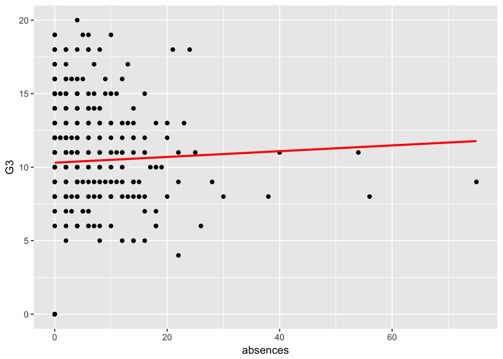

```r
# fit a linear model for G3 using absences
absences_linear_model <- lm(G3 ~ absences, data=uci_data)
# get coefficients from model
absences_parameters = tidy(absences_linear_model)$estimate
# calculate predictions from model
absences_model_data <- uci_data %>%
  mutate(
    absences_lm_prediction = absences_parameters[1] + absences_parameters[2] * uci_data$absences
  )
# plot data and predictions
ggplot(absences_model_data , aes(absences)) +
  geom_point(aes(y = G3)) +
  geom_line(aes(y = absences_lm_prediction), size = 1, color = "red")
```

The absences versus G3 data is quite concentrated on the left side of the graph, but has some outliers to the right because a few students have an unusually high number of absences. The linear model included over the points indicates there is a positive relationship between a student’s number of absences and their final grades, which does not make much sense. As students, we know that if you go to class it is usually easier to do well.

```r
cor(as.numeric(uci_data$absences), uci_data$G3)
```

```
## [1] 0.03424732
```

The correlation coefficient is quite small which indicates there is not a significant correlation between absences and final grades for this data.

Below we use two different objective functions to fit a linear model and compare their residuals.

```r
# get predicted value by model
absences_lm_function <- function(a, data) {
  a[1] + data$absences * a[2]
}

# measure distance between actual and predicted using root-mean-squared deviation
absences_measure_distance <- function(mod_params, data) {
  diff <- data$G3 - absences_lm_function(mod_params, data)
  sqrt(mean(diff ^ 2))
}
# minimize distance between to find best model using root-mean-squared deviation
absences_best <- optim(c(0, 0), absences_measure_distance, data = absences_model_data)
# values for the coefficients
absences_best$par
```

```
## [1] 10.30396698  0.01968196
```

```r
# coefficients of lm()
absences_parameters
```

```
## [1] 10.30326664  0.01960518
```

The coefficients from using the squares of the root-mean-squared method are very similar to the coefficients from the lm() model.

```r
# measure distance between actual and predicted using mean absolute deviation
absences_measure_mad <- function(mod_params, data) {
  diff <- data$G3 - absences_lm_function(mod_params, data)
  mean(abs(diff))
}
# minimize distances to find best model using mad
absences_mad_fit <- optim(c(0, 0), absences_measure_mad, data = absences_model_data)
# values for mad coefficients
absences_mad_fit$par
```

```
## [1] 11.05478542 -0.02739677
```

The coefficients from the mean absolute deviation method are noticably different from the two sets of coefficients above. The most noticable difference is that the slope calculated using mean absolute deviation is negative, which fits the idea that there should be a negative correlation between number of absences and final grades.

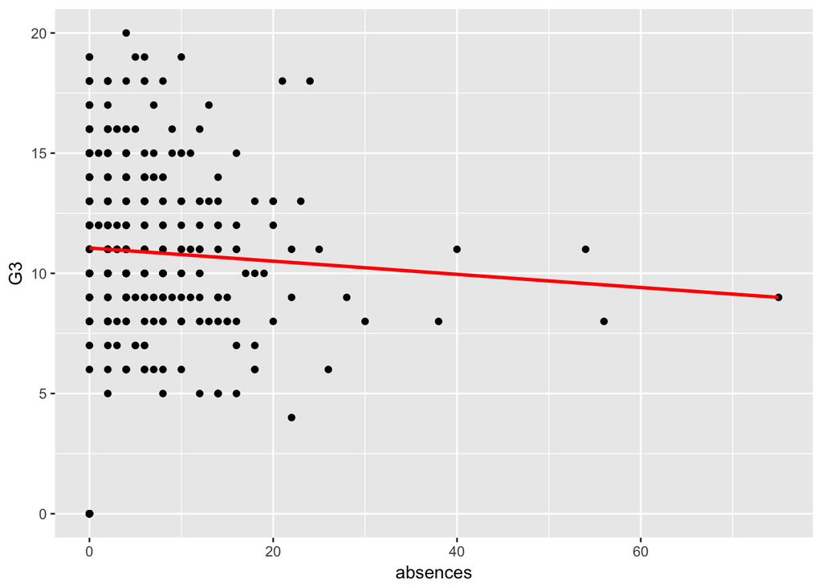

```r
# add mad predictions to data
absences_model_data <- absences_model_data %>%
  mutate(lm_mad_prediction = absences_mad_fit$par[1] + absences_mad_fit$par[2] * uci_data$absences)

# plot mad model
ggplot(absences_model_data , aes(absences)) +
  geom_point(aes(y = G3)) +
  geom_line(aes(y = lm_mad_prediction), size = 1, color = "red")
```

If we plot this linear model over the data, it seems to fit the distribution of points better than the linear model above. This is because the mean absolute deviation is less sensitive to the outliers in this set of data. However, to learn which model is actually a better fit, we can compare their residuals.

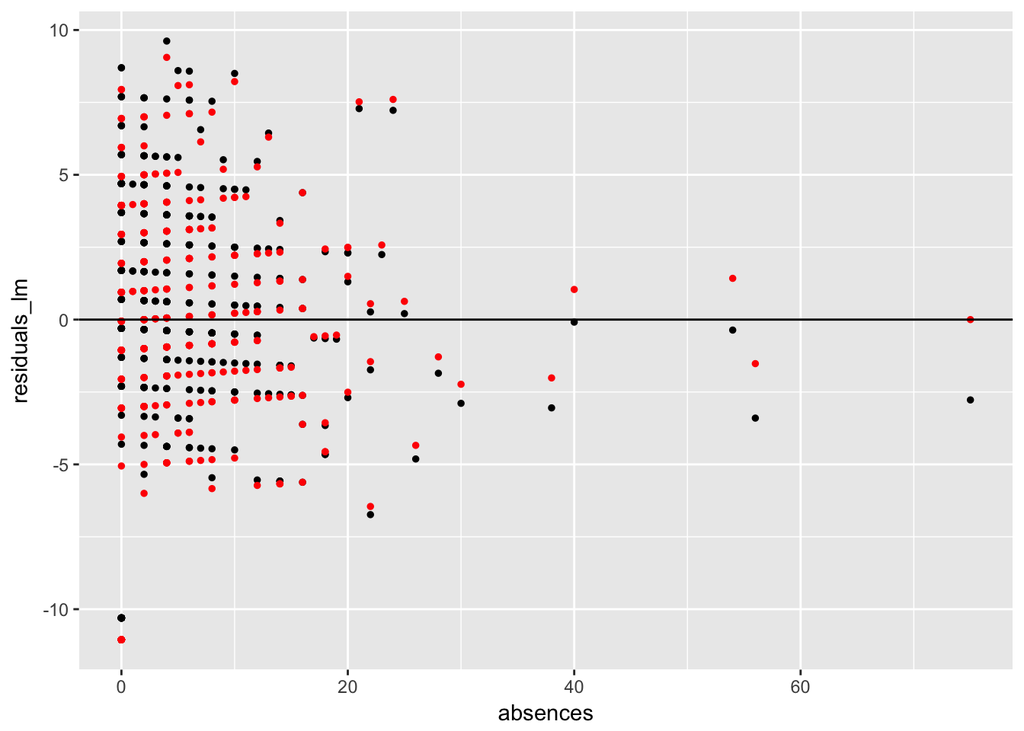

```r
# add both sets of residuals to data
absences_model_data <- absences_model_data %>%
  mutate(
        residuals_lm = G3 - absences_lm_prediction,
        residuals_mad = G3 - lm_mad_prediction
  )

# plot residuals
ggplot(absences_model_data, aes(absences)) +
  geom_point(aes(y=residuals_lm), size = 1) +
  geom_point(aes(y=residuals_mad), color = "red", size = 1) +
  geom_abline(intercept=0, slope = 0)
```

The residuals for the model created using lm() are shown in black and the residuals for the model created using mean absolute deviation are shown in red. The red residual points appear to be slightly closer to zero for many of the points, especially on the upper-left part of the graph where the points are more highly concentrated. There is no clear pattern in the residuals in either case, which indicates a linear model is in fact appropriate for this data.

#### Michigan Dataset

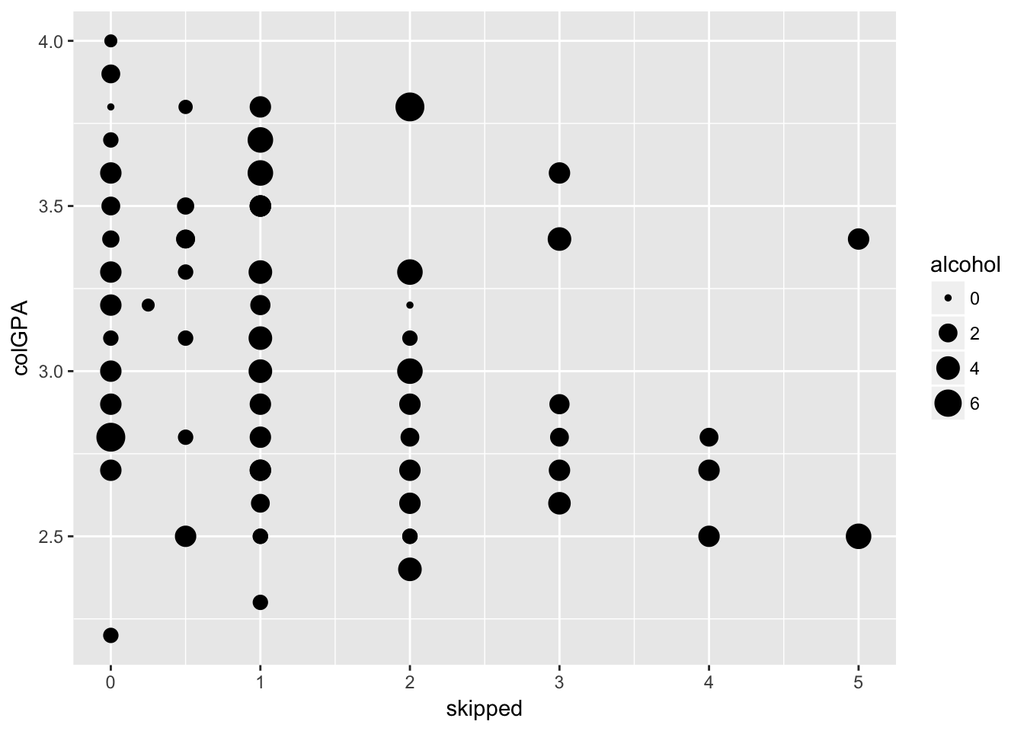

```r
# skipped vs colGPA plot
skip_plot <- ggplot(mich_data, aes(x = skipped, y = colGPA, size=alcohol))  +
  geom_point()
skip_plot
```

The data points are more concentrated to the left of the graph, meaning that most of our participants did not skip class frequently. We also used plot point size to signify the amount the student drank, and the points are fairly scattered, meaning that people who drink alcohol more frequently do not necessarily mean that they skip class more often.

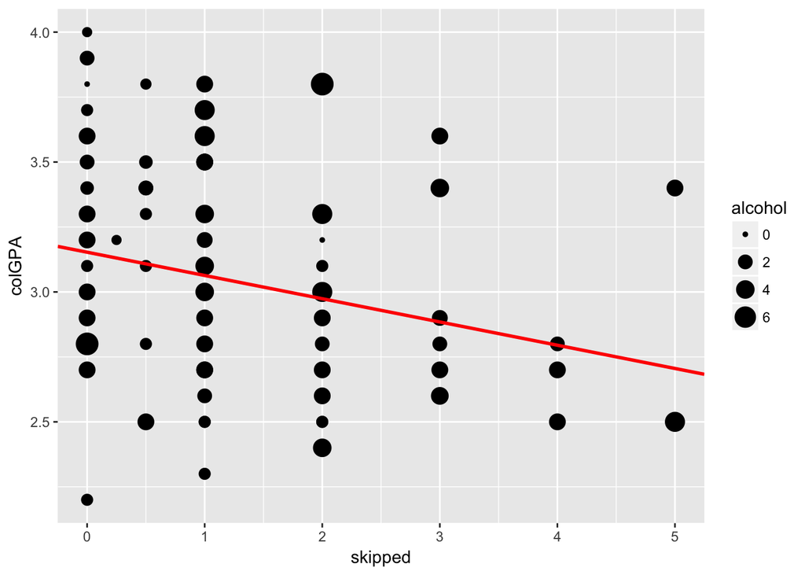

```r
# skipped vs colGPA linear model
linearMod_skip <- lm(colGPA ~ skipped, data=mich_data)
# coefficients from model
skipped_parameters <- tidy(linearMod_skip)$estimate
# scatterplot with linear model
skip_plot + geom_abline(slope=skipped_parameters[2], intercept = skipped_parameters[1], size = 1, color = "red")
```

```r
# correlation
cor(mich_data$skipped,mich_data$colGPA)
```

```
## [1] -0.26182
```

We created a linear regression plot showing the relationship between skipped classes and college GPA, and the graph had a negetive regression slope, which signified that people who skipped more would have a worse GPA. The correlation value of -0.26 means that there is a significant negative relationship between the two factors, and this correlation is much stronger compared to the correlation between alcohol and college GPA.

#### Sleep Study Dataset

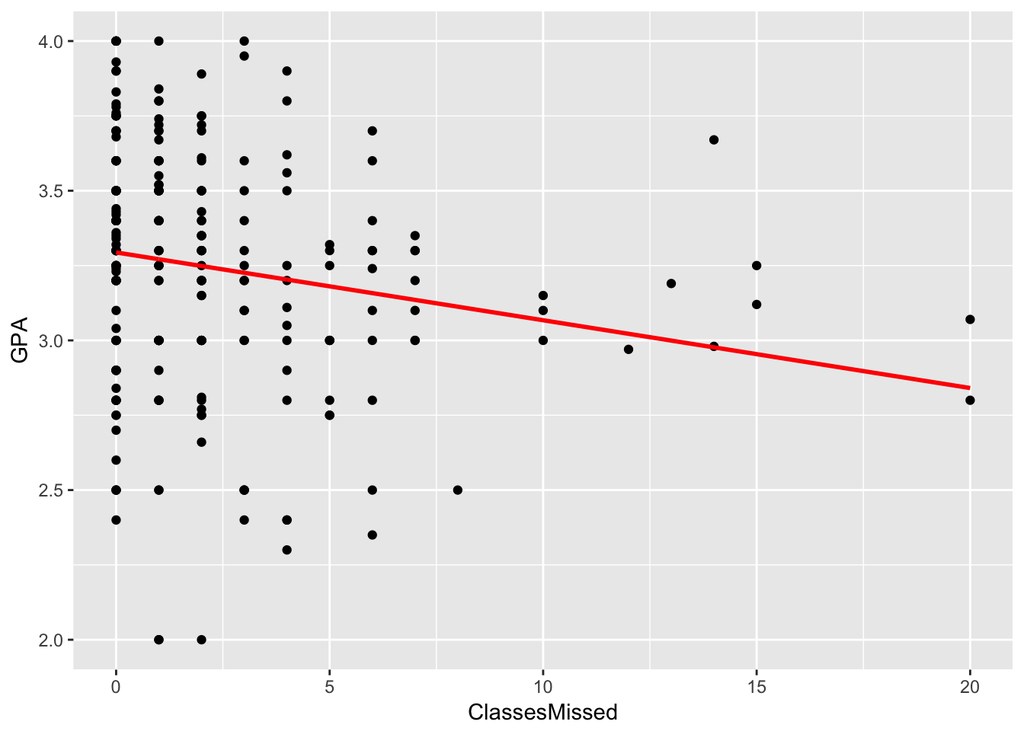

```r
#Class_skipped analysis

missed_linear_model <- lm(GPA ~ ClassesMissed, data = sleep_data)

missed_parameters <- tidy(missed_linear_model)$estimate

sleep_data_small <- sleep_data %>%
  dplyr::select(ClassesMissed, GPA) %>%
  mutate(missed_lm_prediction = missed_parameters[1] + missed_parameters[2] * sleep_data$ClassesMissed)

ggplot(sleep_data_small , aes(ClassesMissed)) +
  geom_point(aes(y= GPA)) +
  geom_line(aes(y= missed_lm_prediction), size = 1, colour = "red")
```

This scatterplot shows a linear model over the number of classes missed versus student GPAs from the sleep study dataset. Similar to the previous two datasets, the points are more highly concentrated to the left side of the graph meaning most participants did not skip class very frequently. While there are a wide range of GPAs despite number of classes missed, the linear model indiates that there is a slightly negative correlation between the number of classes missed and GPA.

```r
missed_lm_function <- function(a, data) {
  a[1] + data$ClassesMissed * a[2]
}

missed_measure_distance <- function(mod_params, data) {
  diff <- data$GPA - missed_lm_function(mod_params, data)
  sqrt(mean(diff ^ 2))
}

# line fit with squares of the residuals
missed_best <- optim(c(3.4, 0), missed_measure_distance, data = sleep_data_small)

# values for the coefficients
missed_best$par
```

```
## [1]  3.29379084 -0.02264939
```

```r
# from lm() function
missed_parameters
```

```
## [1]  3.29384061 -0.02265058
```

We tried using a different method to fit a linear model to this data and found that the coefficients from using the root-mean-squared method are very similar to the coefficients from the lm() model.

```r
missed_measure_distance_mad <- function(mod_params, data) {
  diff <- data$GPA - missed_lm_function(mod_params, data)
  mean(abs(diff))
}

# make use of a different distance function here (such as mean absolute)
missed_mad_fit <- optim(c(3.4, 0), missed_measure_distance_mad, data = sleep_data_small)
missed_mad_fit$par
```

```
## [1]  3.33997850 -0.02399788
```

Using the mean absolute deviation method to fit a linear model to this data also produces slightly different results, but is similar enough for our purposes.

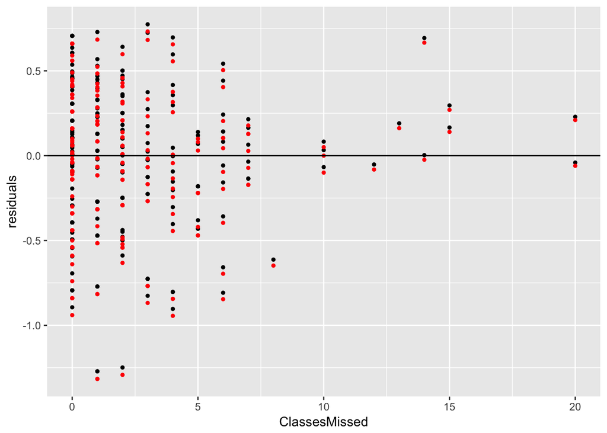

```r
sleep_data_small <- sleep_data_small %>%
  mutate(lm_mad = missed_mad_fit$par[1] + missed_mad_fit$par[2] * sleep_data$ClassesMissed)

sleep_data_small <- sleep_data_small %>%
  mutate(
    residuals_mad = GPA - lm_mad,
    residuals = GPA - missed_lm_prediction
  )

# plot the residuals to compare them
ggplot(sleep_data_small, aes(ClassesMissed)) +
  geom_point(aes(y=residuals), size = 1) +
  geom_point(aes(y=residuals_mad), color = "red", size = 1) +
  geom_abline(intercept=0, slope = 0)
```

The residuals for the model created using lm() are shown in black and the residuals for the model created using mean absolute deviation are shown in red. The two sets of residuals are very similar, however the mean absolute deviation residuals are slightly closer to zero for values above the linear model and slightly further from zero for values below the linear model. For both sets of residuals there is no clear pattern in the points, which shows that a linear model was appropriate for modeling this data.

```r
cor(sleep_data$ClassesMissed, sleep_data$GPA)
```

```
## [1] -0.1815426
```

```r
cor(sleep_data$ClassesMissed, sleep_data$Drinks)
```

```
## [1] 0.07830198
```

#### Summary

Across all three of our datasets, we determined that there is a negative correlation between the number of classes a student skips and their GPA. While we only saw a negative correlation between the number of absences and final grades for the UCI dataset when using the mean absolute deviation method, the other two datasets showed a clear negative correlation between the two variables. This makes sense because if you aren’t going to class you usually have to work harder to catch up and learn the material that you missed and this can impact your grades.

## Results

While our analysis on how alcohol consumption affects college students’ grades was inconclusive across the three different datasets, we were able to triangulate our results on how the number of classes missed is correlated with final grades. In the end, our analysis showed that attending class is more relevant to final grades than drinking. Based on these results, our suggestion for college students who are deciding how they should drink throughout the quarter if they want to optimize their GPA is that they should drink on the condition that they go to class. If students are drinking so much that they are too hungover in the morning to go to class, it will probably have a negative impact on their grades. However, if students chose to drink responsibly such that they are still able to go to class, they will be more likely to get good grades. Ultimately, we acknowledge that students should make their own decisions regarding alcohol, but we encourage them to go to class if they want to optimize their GPA.

### Limitations

When searching for data to use for our study we learned that there is limited data available on the subject matter specific to drinking and its direct relation to grades for college students. One major limitation that we faced was that it was hard to connect all three datasets together because they all came from different contexts and measured different features so their important actors were all different.

The UCI dataset was particularly unhelpful because it represents the drinking behaviors of high school students from a different country, which we think is quite distinct from college students in the United States.

For the Michigan dataset, we were only given the amount of days that they consumed alcohol, and an issue with that is that we cannot quantify how much alcohol that the students drank. If a student drank 7 days, it could have meant that he could have only had a single beer every night, which would cause different effects than if someone consumed 5 beers each night for 4 nights, even though the data would lead us to believe that the person who reported 7 days would drink more.

For the sleep dataset, we would have the a similar but opposite issue compared to the Michigan dataset as they report drinks consumed per week but not days they drank. If we look at two participants who consumed 15 drinks in a week, the affects would be different for a participant who consumed around 2 drinks a day for 7 days than a participant who consumed 5 drinks a day for 3 days.

Another issue that we were not able to look into from the dataset is a hangover. The drinking data we look into sees the amount of drinks a person consumed or how often a person consumes alcohol, but we do not get to look into reprucussions that drinking can cause, such as hangovers. Hangovers can cause headaches, drowsiness, concentration issues, and other symptoms from periods of time that could last from 4 hours to an entire day. These symptoms would also detract student learning as they would not be able to concentrate on the material but rather focus on the discomfort that they are experiencing, and this phenomenon would provide more detrimental to a student’s GPA than the act of drinking alcohol.

As we did not collect the data in these three datasets ourselves, it was impossible for us to know exactly the types of drinks people consumed, exactly how frequently they drink throughout a school term, and also how drunk they actually get. Because the data we used had limited information, we had to assume that the number of drinks or days of drinking is representative of drinking behavior without knowing exactly how much someone drank at a given time.

## Future Work

A more controlled experiment would certainly give us more insight on the relationship between alcohol and students’ grades. In future studies, it would be interesting to track more distinct and exhaustive factors, such as the frequency, specific days of week, and number of standard drinks consumed by a much more consistent population of college students. An experiment of this design would help gain a deeper understanding about the relationships between each factor and grades.

Other important factors that we want to explore are the quesitons about what type of alcohol is consumed and whether drinking alcohol will affect performance consistently across different people. The type of drink is important becuase there are many other food chemicals that will have significant effectos on brain activity that should be accounted for. There may also be some relevant and underlying social behavior associated with drinking for different people, so it would also be interesting to pay more attention to the number of drinks a person has, what type of drinks they are having, how often they drink, and their body weight for calculating BAC (standard measure of drunkeness across different people) when collecting data. If the time that a drink is taken is also recorded for students, we could also gain more insights about how different behaviors, like binge drinking compared to moderate drinking, affect grades. Future studies should track exactly how much participants drink because different amounts of alcohol affect people differently and some people have different defintitions of what they would consider “light” or “heavy” drinking.